# PracticalMachineLearning

Allen K H

December 28, 2016

## Introduction

Wearables allow tracking of a multitude of physical movements. Using the variety of features available, we will try to model the “quality” of the movements. We use a dataset with the an additional column called Class (labeled classe in the dataset) According to http://groupware.les.inf.puc-rio.br/har

Class A - Correct Form Class B - throwing the elbows to the front Class C - lifting the dumbbell only halfway Class D - lowering the dumbbell only halfway Class E - throwing the hips to the front

Using the Class column, we can build a model to measure the quality of movements recorded in wearables.

## Data

```r
library(data.table)
library(caret)
##Read In Data
train<-fread("pml-training.csv",header=TRUE, drop = 1,colClasses=list(numeric=7:158),na.string=c("NA",""))
```

```
##
Read 0.0% of 19622 rows
Read 19622 rows and 159 (of 160) columns from 0.011 GB file in 00:00:03
```

```r
train$classe<-factor(train$classe)
```

Looking at the summary, there seems to be frequent NAs over several columns.

```r
freqNA<-data.frame(colnames(train),colSums(!is.na(train))/nrow(train))
colnames(freqNA)<-c("colnames","freq")
rownames(freqNA) <- NULL
head(freqNA)
```

```
##               colnames freq
## 1            user_name    1
## 2 raw_timestamp_part_1    1
## 3 raw_timestamp_part_2    1
## 4       cvtd_timestamp    1
## 5           new_window    1
## 6           num_window    1
```

It is suspicious that it is either 0.02069106 or 1.000 of values that are not NAs. The columns with very large NAs will be omitted from the model, as these will cause a lot of noise.

## Building the Model

Given that we are modeling the Class factor, Random Forest will be used. The model will be appropriate given that we are modeling for a classifier with more than 2 levels. Furthermore, all features will be used except: 1. Those columns with large volumes of NA 2. Columns that have are not non-numeric, such as user_name since we do not want the model to be user specific, rather generalized for the population.

```r
##Numeric Column-types Only and Columns with Minimal NAs
colData<-train[,(colSums(!is.na(train))/nrow(train) > 0.5),with=FALSE]
cols = sapply(colData, is.numeric)
cols = names(cols)[cols]

##Random Forest
f <- as.formula(paste(names(train)[159], "~", paste(cols, collapse=" + "))) ##ONLY INCLUDE NUMERIC
set.seed(123)
modelRF<-train(f,data=train,method='rf',importance=TRUE,ntree=40)
```

## Model Summary

Our Training Model results show that the OOB estimate is 0.09% and the Confusion matrix show accurate results.

```r
print(modelRF$finalModel)
```

```
##
## Call:
##  randomForest(x = x, y = y, ntree = 40, mtry = param$mtry, importance = TRUE)
##                Type of random forest: classification
##                      Number of trees: 40
## No. of variables tried at each split: 28
##
##         OOB estimate of  error rate: 0.09%
## Confusion matrix:
##      A    B    C    D    E class.error
## A 5580    0    0    0    0 0.000000000
## B    1 3791    4    1    0 0.001580195
## C    0    4 3417    1    0 0.001461134
## D    0    0    4 3209    3 0.002176617
## E    0    0    0    0 3607 0.000000000
```

## Variable Importance

We can plot the variable importance to visually rank the feature importance.

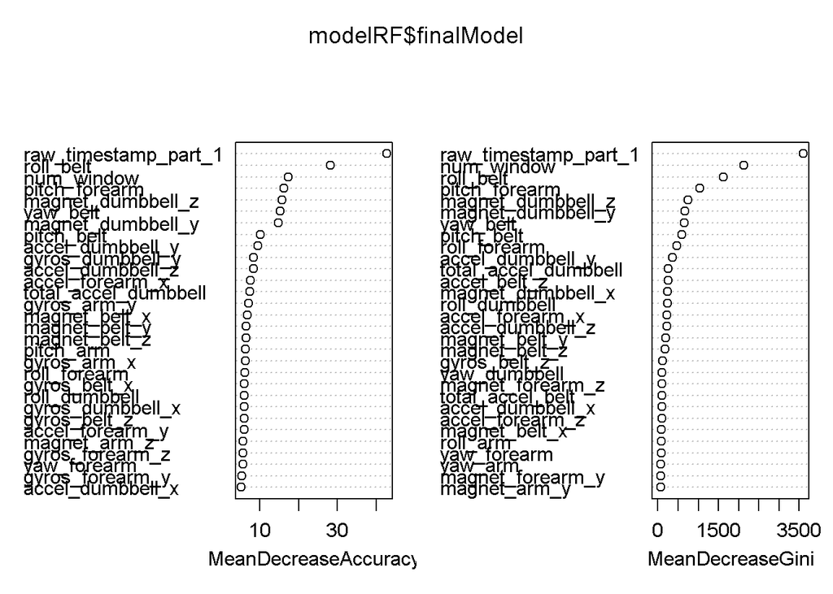

## Predict Test Set

We import the test dataset and run the model through to get predicted Class values.

```r
test<-fread("pml-testing.csv",header=TRUE,drop = 1,colClasses=list(numeric=7:158),na.string=c("NA",""))

predictRF<-predict(modelRF,test)
print(predictRF)
```

```
##  [1] B A B A A E D B A A B C B A E E A B B B
## Levels: A B C D E
```